# Task 1 – Dimensionality reduction

```python
import pandas as pd
import matplotlib.pyplot as plt
import numpy as np
from sklearn.manifold import MDS
import seaborn as sns
from sklearn.metrics.pairwise import manhattan_distances, euclidean_distances
from matplotlib.offsetbox import OffsetImage, AnnotationBbox
from sklearn.decomposition import PCA
origin_data = pd.read_csv('IE582_Fall21_HW2_q1_data.csv')
```

```python
print(type(origin_data))
print(origin_data.shape)
print(origin_data.columns)
```

```
<class 'pandas.core.frame.DataFrame'>
(198, 3)
Index(['X1', 'X2', 'class'], dtype='object')
```

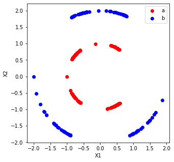

```python
#Visualization of the dataset
a = origin_data.groupby('class')
a.get_group('a')
plt.figure(figsize=(5,5))
plt.scatter(a.get_group('a')['X1'], a.get_group('a')['X2'], c='r')
plt.scatter(a.get_group('b')['X1'], a.get_group('b')['X2'], c='b')
plt.legend(["a" , "b"])
plt.xlabel("X1")
plt.ylabel("X2")
```

a) Apply PCA to reduce the number of dimensions to one and visualize the instances on a scatter plot. Note that the scatter plot will show the observation number versus the observed value (as we have a single feature to represent the instance).

```python
pca = PCA(n_components=1)
pca_data=pca.fit_transform(origin_data.iloc[:,[0,1]])
pca_data=pd.DataFrame(pca_data)
```

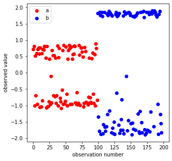

```python
pca_data["pca"]=pd.DataFrame(pca_data)
pca_data["index no"]=pca_data.index
pca_data["class"]=origin_data['class']
pca_data=pca_data.drop(pca_data.columns[0], axis=1)

b = pca_data.groupby('class')
plt.figure(figsize=(5,5))
plt.scatter(b.get_group('a')['index no'], b.get_group('a')['pca'], c='r')
plt.scatter(b.get_group('b')['index no'], b.get_group('b')['pca'], c='b')
plt.legend(["a" , "b"])
plt.xlabel("observation number")
plt.ylabel("observed value")
```

b) Apply MDS to reduce the number of dimensions to one and visualize the instances on a scatter plot as in part (a). Use at least two different similarity measure.

```python
#default is euclidean
mds = MDS(1)
data_transform=mds.fit_transform(origin_data.iloc[:,[0,1]])
data_transform=pd.DataFrame(data_transform)
```

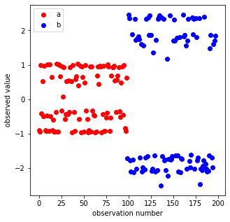

```python
data_transform["mds"]=pd.DataFrame(data_transform)
data_transform["index no"]=data_transform.index
data_transform["class"]=origin_data['class']
data_transform=data_transform.drop(data_transform.columns[0], axis=1)

c = data_transform.groupby('class')
plt.figure(figsize=(5,5))
plt.scatter(c.get_group('a')['index no'], c.get_group('a')['mds'], c='r')
plt.scatter(c.get_group('b')['index no'], c.get_group('b')['mds'], c='b')
plt.legend(["a" , "b"])
plt.xlabel("observation number")
plt.ylabel("observed value")
```

```python
dist_manhattan = manhattan_distances(origin_data.iloc[:,[0,1]])
mds2 = MDS(n_components=1, dissimilarity="precomputed")
data_transform2=mds2.fit_transform(dist_manhattan)
data_transform2=pd.DataFrame(data_transform2)
```

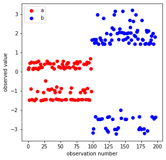

```python
data_transform2["mds2"]=pd.DataFrame(data_transform2)
data_transform2["index no"]=data_transform2.index
data_transform2["class"]=origin_data['class']
data_transform2=data_transform2.drop(data_transform2.columns[0], axis=1)

d = data_transform2.groupby('class')
plt.figure(figsize=(5,5))
plt.scatter(d.get_group('a')['index no'], d.get_group('a')['mds2'], c='r')
plt.scatter(d.get_group('b')['index no'], d.get_group('b')['mds2'], c='b')
plt.legend(["a" , "b"])
plt.xlabel("observation number")
plt.ylabel("observed value")
```

c) On a 2D scatter plot, one can observe how two observations from two classes are different.

1. What is your conclusion when you use PCA results in single dimension (your results from part a)?
2. What is your conclusion when you use MDS results in single dimension (your results from part b)? Compare the results from different similarity measures used in part (b)
3. Compare MDS results with PCA. What is your conclusion?
1. PCA results provide a good result about classification. For some data, there are some outliers however it has high accuracy.
2. MDS results also provide a good solution. It makes a perfect clasification.
3. MDS is better than PCA for the classifciation.

d) Suppose, you are not satisfied with your dimensionality reduction scheme in part (a). Add the following columns to your data, X 1 2 , X2 2 , X 1× X 2 (three columns as functions of your original variables) and apply PCA. Comment on the PCA results (i.e. what are the eigenvalues? What do they refer to?).

```python
new_data=origin_data.iloc[:,[0,1]]
new_data["X1^2"]=origin_data['X1']*origin_data['X1']
new_data["X2^2"]=origin_data['X2']*origin_data['X2']
new_data["X1*X2"]=origin_data['X1']*origin_data['X2']
new_data["class"]=origin_data['class']
new_data.head()
```

|  | X1 | X2 | X1^2 | X2^2 | X1*X2 | class |
| --- | --- | --- | --- | --- | --- | --- |
| 0 | 0.569483 | 0.822003 | 0.324311 | 0.675689 | 0.468117 | a |
| 1 | 0.411469 | 0.911424 | 0.169307 | 0.830693 | 0.375023 | a |
| 2 | 0.417385 | -0.908730 | 0.174210 | 0.825790 | -0.379290 | a |
| 3 | -0.791828 | 0.610745 | 0.626991 | 0.373009 | -0.483604 | a |
| 4 | -0.806777 | -0.590857 | 0.650889 | 0.349111 | 0.476689 | a |

```python
pca_new = PCA(n_components=5)
pca_data_new=pca_new.fit_transform(new_data.iloc[:,[0,1,2,3,4]])
pca_data_new=pd.DataFrame(pca_data_new)
```

```python
print("eigenvalues are = ", pca_new.explained_variance_)
print("ratios are = ", pca_new.explained_variance_ratio_)
print("eigenvectors are = ", pca_new.components_)
```

```
eigenvalues are =  [2.49086525 1.44256642 1.28808119 0.54559809 0.30619998]
ratios are =  [0.410133   0.23752553 0.21208879 0.08983536 0.05041731]
eigenvectors are =  [[ 0.07766657  0.71257596 -0.19184503  0.66582496 -0.07794878]
 [-0.42317217 -0.07426701  0.15328013  0.27219612  0.84724507]
 [ 0.21930469 -0.6092683   0.27145989  0.67993125 -0.21142519]
 [-0.73210164  0.13942364  0.49110581  0.0249689  -0.45031087]
 [ 0.4804434   0.30995661  0.79045892 -0.14020145  0.16917239]]
```

# Task 2 – Reconstructing Turkey Map

Suppose we apply MDS to this data to distance matrix to obtain latent variables in 2D dimensional space. Represent the new feature space on a 2D plot. You are expected to label each data point with the respective city’s name. This plot should be similar to Turkey map. Are there any unusual observations? If yes, comment on your findings.

```python
turkey_origin=pd.read_excel("ilmesafe.xls", header=2)
```

```python
turkey=turkey_origin.fillna(0)
turkey=turkey.drop(columns=['İL PLAKA NO', 'İL ADI'])
```

```python
m = np.tril(turkey) + np.tril(turkey, -1).T
sym_turkey =pd.DataFrame(m)
```

```python
(m==m.T).all()
```

```
True
```

```python
mds_turkey = MDS(n_components=2, dissimilarity="precomputed")
turkey_transform=mds_turkey.fit_transform(sym_turkey)
turkey_transform=pd.DataFrame(turkey_transform)
```

```python
turkey_transform["Şehir"]=turkey_origin['İL ADI']
```

```python
turkey_transform.set_axis(['mds1', 'mds2', 'Şehir'], axis=1, inplace=True)
turkey_transform.head()
```

|  | mds1 | mds2 | Şehir |
| --- | --- | --- | --- |
| 0 | -172.321104 | 335.349227 | ADANA |
| 1 | -485.110014 | 198.068634 | ADIYAMAN |
| 2 | 414.367052 | 270.345960 | AFYONKARAHİSAR |
| 3 | -716.262486 | -385.684396 | AĞRI |
| 4 | 30.532466 | -199.499254 | AMASYA |

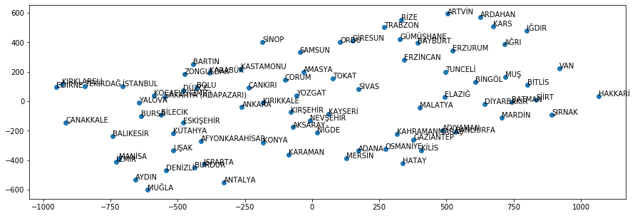

```python
plt.figure(figsize=(15,5))
plt.scatter(-turkey_transform.mds1, -turkey_transform.mds2)
for txt, x, y in zip(turkey_transform["Şehir"], turkey_transform["mds1"], turkey_transform["mds2"]):
    plt.annotate(txt, (-x,-y))
plt.show()
```

It seems like little bit unusual due to the real turkey map. The left part should be higher and the right part should be lower. On the other hand, the positions of the cities relatively to the each other are right.

# Task 3 – Dimensionality reduction for time series data

a) Read the data and visualize one instance (all axes) from each class and try to relate the shape (time series) you see with the gestures shown in Figure 1 (this is just for fun, sometimes it is good to start with data visualization to understand what is going on). A 3D scatter plot would be interesting. Note that this is an acceleration information. You can transform this information to a velocity vector by computing the cumulative sum of acceleration over time. A cumulative sum operation on the velocity values will transform the series to a position information.

```python
X_gesture_org = pd.read_csv('uWaveGestureLibrary_X_TRAIN', sep=" ", prefix="t", header=None, skipinitialspace=True)
Y_gesture_org = pd.read_csv('uWaveGestureLibrary_Y_TRAIN', sep=" ", prefix="t", header=None, skipinitialspace=True)
Z_gesture_org = pd.read_csv('uWaveGestureLibrary_Z_TRAIN', sep=" ", prefix="t", header=None, skipinitialspace=True)
```

```python
X_gesture=X_gesture_org.drop(X_gesture_org.columns[0], axis=1)
X_gesture["class"]=X_gesture_org.t0.astype("category")
Y_gesture=Y_gesture_org.drop(Y_gesture_org.columns[0], axis=1)
Y_gesture["class"]=Y_gesture_org.t0.astype("category")
Z_gesture=Z_gesture_org.drop(Z_gesture_org.columns[0], axis=1)
Z_gesture["class"]=Z_gesture_org.t0.astype("category")
```

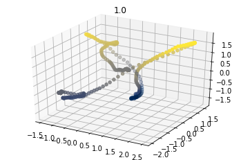

```python
groupX=X_gesture.iloc[10,:]
groupY=Y_gesture.iloc[10,:]
groupZ=Z_gesture.iloc[10,:]
groupXYZ=pd.concat([groupX,groupY,groupZ], axis=1).T
groupXYZ.set_axis(['X', 'Y', 'Z'], axis=0, inplace=True)
group1=groupXYZ.drop(groupXYZ.columns[315], axis=1).T

from mpl_toolkits import mplot3d
fig = plt.figure()
ax = plt.axes(projection='3d')


# Data for three-dimensional scattered points
zdata = list(group1.Z)
xdata = list(group1.X)
ydata = list(group1.Y)
ax.scatter3D(xdata, ydata, zdata, c=zdata, cmap='cividis');
ax.set_title("1.0")
```

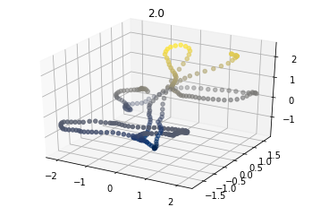

```python
groupX=X_gesture.iloc[14,:]
groupY=Y_gesture.iloc[14,:]
groupZ=Z_gesture.iloc[14,:]
groupXYZ=pd.concat([groupX,groupY,groupZ], axis=1).T
groupXYZ.set_axis(['X', 'Y', 'Z'], axis=0, inplace=True)
group2=groupXYZ.drop(groupXYZ.columns[315], axis=1).T

from mpl_toolkits import mplot3d
fig = plt.figure()
ax = plt.axes(projection='3d')


# Data for three-dimensional scattered points
zdata = list(group2.Z)
xdata = list(group2.X)
ydata = list(group2.Y)
ax.scatter3D(xdata, ydata, zdata, c=zdata, cmap='cividis');
ax.set_title("2.0")
```

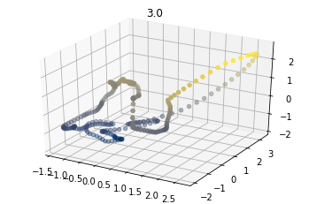

```python
groupX=X_gesture.iloc[3,:]
groupY=Y_gesture.iloc[3,:]
groupZ=Z_gesture.iloc[3,:]
groupXYZ=pd.concat([groupX,groupY,groupZ], axis=1).T
groupXYZ.set_axis(['X', 'Y', 'Z'], axis=0, inplace=True)
group3=groupXYZ.drop(groupXYZ.columns[315], axis=1).T

from mpl_toolkits import mplot3d
fig = plt.figure()
ax = plt.axes(projection='3d')


# Data for three-dimensional scattered points
zdata = list(group3.Z)
xdata = list(group3.X)
ydata = list(group3.Y)
ax.scatter3D(xdata, ydata, zdata, c=zdata, cmap='cividis');
ax.set_title("3.0")
```

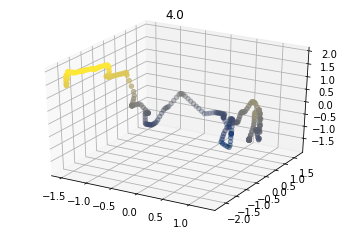

```python
groupX=X_gesture.iloc[4,:]
groupY=Y_gesture.iloc[4,:]
groupZ=Z_gesture.iloc[4,:]
groupXYZ=pd.concat([groupX,groupY,groupZ], axis=1).T
groupXYZ.set_axis(['X', 'Y', 'Z'], axis=0, inplace=True)
group4=groupXYZ.drop(groupXYZ.columns[315], axis=1).T

from mpl_toolkits import mplot3d
fig = plt.figure()
ax = plt.axes(projection='3d')


# Data for three-dimensional scattered points
zdata = list(group4.Z)
xdata = list(group4.X)
ydata = list(group4.Y)
ax.scatter3D(xdata, ydata, zdata, c=zdata, cmap='cividis');
ax.set_title("4.0")
```

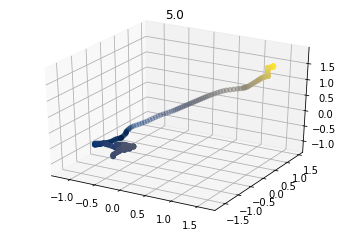

```python
groupX=X_gesture.iloc[1,:]
groupY=Y_gesture.iloc[1,:]
groupZ=Z_gesture.iloc[1,:]
groupXYZ=pd.concat([groupX,groupY,groupZ], axis=1).T
groupXYZ.set_axis(['X', 'Y', 'Z'], axis=0, inplace=True)
group5=groupXYZ.drop(groupXYZ.columns[315], axis=1).T

from mpl_toolkits import mplot3d
fig = plt.figure()
ax = plt.axes(projection='3d')


# Data for three-dimensional scattered points
zdata = list(group5.Z)
xdata = list(group5.X)
ydata = list(group5.Y)
ax.scatter3D(xdata, ydata, zdata, c=zdata, cmap='cividis');
ax.set_title("5.0")
```

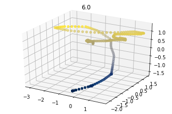

```python
groupX=X_gesture.iloc[0,:]
groupY=Y_gesture.iloc[0,:]
groupZ=Z_gesture.iloc[0,:]
groupXYZ=pd.concat([groupX,groupY,groupZ], axis=1).T
groupXYZ.set_axis(['X', 'Y', 'Z'], axis=0, inplace=True)
group6=groupXYZ.drop(groupXYZ.columns[315], axis=1).T

from mpl_toolkits import mplot3d
fig = plt.figure()
ax = plt.axes(projection='3d')


# Data for three-dimensional scattered points
zdata = list(group6.Z)
xdata = list(group6.X)
ydata = list(group6.Y)
ax.scatter3D(xdata, ydata, zdata, c=zdata, cmap='cividis');
ax.set_title("6.0")
```

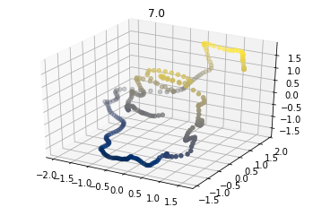

```python
groupX=X_gesture.iloc[6,:]
groupY=Y_gesture.iloc[6,:]
groupZ=Z_gesture.iloc[6,:]
groupXYZ=pd.concat([groupX,groupY,groupZ], axis=1).T
groupXYZ.set_axis(['X', 'Y', 'Z'], axis=0, inplace=True)
group7=groupXYZ.drop(groupXYZ.columns[315], axis=1).T

from mpl_toolkits import mplot3d
fig = plt.figure()
ax = plt.axes(projection='3d')


# Data for three-dimensional scattered points
zdata = list(group7.Z)
xdata = list(group7.X)
ydata = list(group7.Y)
ax.scatter3D(xdata, ydata, zdata, c=zdata, cmap='cividis');
ax.set_title("7.0")
```

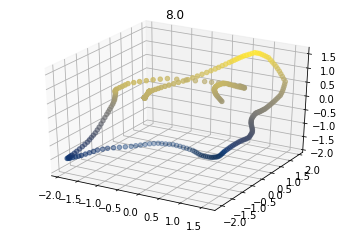

```python
groupX=X_gesture.iloc[5,:]
groupY=Y_gesture.iloc[5,:]
groupZ=Z_gesture.iloc[5,:]
groupXYZ=pd.concat([groupX,groupY,groupZ], axis=1).T
groupXYZ.set_axis(['X', 'Y', 'Z'], axis=0, inplace=True)
group8=groupXYZ.drop(groupXYZ.columns[315], axis=1).T

from mpl_toolkits import mplot3d
fig = plt.figure()
ax = plt.axes(projection='3d')


# Data for three-dimensional scattered points
zdata = list(group8.Z)
xdata = list(group8.X)
ydata = list(group8.Y)
ax.scatter3D(xdata, ydata, zdata, c=zdata, cmap='cividis');
ax.set_title("8.0")
```

Apply PCA to the time series from each class in the training data. You are expected to filter the data from each class and apply PCA to the representation. Work on the following questions based on your PCA application for the time series from each class. • How much variability can be recovered by the first two components? • Draw the each eigenvector (component) as a time series for each class. What do the eigenvectors imply in this setting? In total, you are expected to provide 8 plots. Each plot is expected to provide two time series (i.e. first eigenvector and the second eigenvector). Are there any interesting patterns/observations? If yes, provide your comments.

```python
allxyz=pd.concat([X_gesture.iloc[:,:315:],Y_gesture.iloc[:,:315:],Z_gesture], axis=1)
```

```
Recovered by the first two components= 0.6339910899351862
```

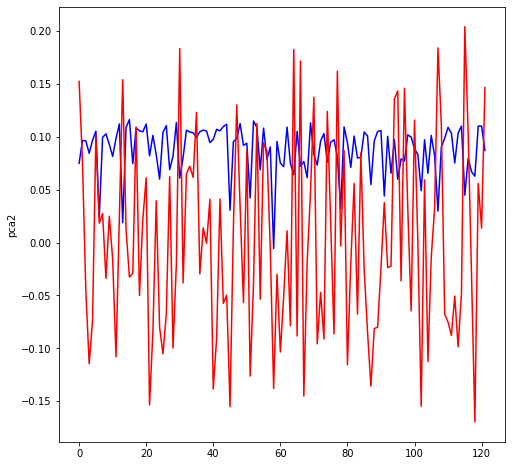

```python
groupg = allxyz[allxyz["class"]==1].drop(["class"], axis=1).T

pca_g = PCA(n_components=2)
pca_data_g=pca_g.fit_transform(groupg)
pca_data_g=pd.DataFrame(pca_data_g)

print("Recovered by the first two components=", np.sum(pca_g.explained_variance_ratio_))

eigenvectorsg=pca_g.components_
eigenvectorsg=pd.DataFrame(eigenvectorsg).T
eigenvectorsg.set_axis(['pca1', 'pca2'], axis=1, inplace=True)
plt.figure(figsize=(8,8))
sns.lineplot(eigenvectorsg.index, eigenvectorsg.pca1, color='b')
sns.lineplot(eigenvectorsg.index, eigenvectorsg.pca2, color='r')
```

```
Recovered by the first two components= 0.6820401423762179
```

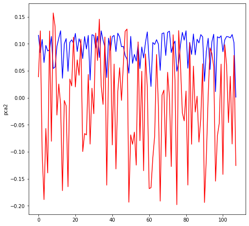

```python
groupg = allxyz[allxyz["class"]==2].drop(["class"], axis=1).T

pca_g = PCA(n_components=2)
pca_data_g=pca_g.fit_transform(groupg)
pca_data_g=pd.DataFrame(pca_data_g)

print("Recovered by the first two components=", np.sum(pca_g.explained_variance_ratio_))

eigenvectorsg=pca_g.components_
eigenvectorsg=pd.DataFrame(eigenvectorsg).T
eigenvectorsg.set_axis(['pca1', 'pca2'], axis=1, inplace=True)
plt.figure(figsize=(8,8))
sns.lineplot(eigenvectorsg.index, eigenvectorsg.pca1, color='b')
sns.lineplot(eigenvectorsg.index, eigenvectorsg.pca2, color='r')
```

```
Recovered by the first two components= 0.594911265289698
```

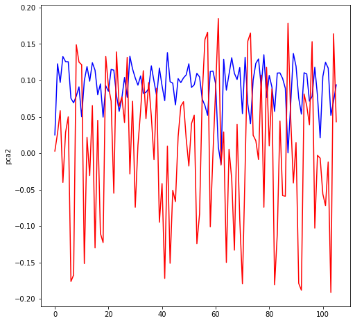

```python
groupg = allxyz[allxyz["class"]==3].drop(["class"], axis=1).T

pca_g = PCA(n_components=2)
pca_data_g=pca_g.fit_transform(groupg)
pca_data_g=pd.DataFrame(pca_data_g)

print("Recovered by the first two components=", np.sum(pca_g.explained_variance_ratio_))

eigenvectorsg=pca_g.components_
eigenvectorsg=pd.DataFrame(eigenvectorsg).T
eigenvectorsg.set_axis(['pca1', 'pca2'], axis=1, inplace=True)
plt.figure(figsize=(8,8))
sns.lineplot(eigenvectorsg.index, eigenvectorsg.pca1, color='b')
sns.lineplot(eigenvectorsg.index, eigenvectorsg.pca2, color='r')
```

```
Recovered by the first two components= 0.5454833281484367
```

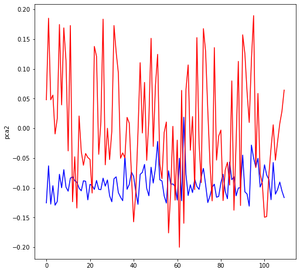

```python
groupg = allxyz[allxyz["class"]==4].drop(["class"], axis=1).T

pca_g = PCA(n_components=2)
pca_data_g=pca_g.fit_transform(groupg)
pca_data_g=pd.DataFrame(pca_data_g)

print("Recovered by the first two components=", np.sum(pca_g.explained_variance_ratio_))

eigenvectorsg=pca_g.components_
eigenvectorsg=pd.DataFrame(eigenvectorsg).T
eigenvectorsg.set_axis(['pca1', 'pca2'], axis=1, inplace=True)
plt.figure(figsize=(8,8))
sns.lineplot(eigenvectorsg.index, eigenvectorsg.pca1, color='b')
sns.lineplot(eigenvectorsg.index, eigenvectorsg.pca2, color='r')
```

```
Recovered by the first two components= 0.6535295336384515
```

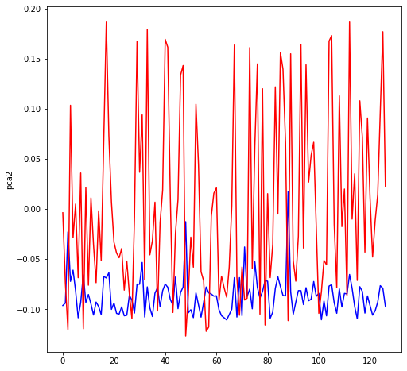

```python
groupg = allxyz[allxyz["class"]==5].drop(["class"], axis=1).T

pca_g = PCA(n_components=2)
pca_data_g=pca_g.fit_transform(groupg)
pca_data_g=pd.DataFrame(pca_data_g)

print("Recovered by the first two components=", np.sum(pca_g.explained_variance_ratio_))

eigenvectorsg=pca_g.components_
eigenvectorsg=pd.DataFrame(eigenvectorsg).T
eigenvectorsg.set_axis(['pca1', 'pca2'], axis=1, inplace=True)
plt.figure(figsize=(8,8))
sns.lineplot(eigenvectorsg.index, eigenvectorsg.pca1, color='b')
sns.lineplot(eigenvectorsg.index, eigenvectorsg.pca2, color='r')
```

```
Recovered by the first two components= 0.5399926780434638
```

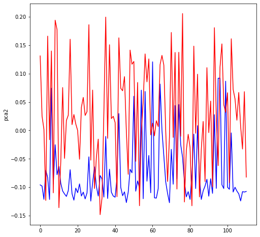

```python
groupg = allxyz[allxyz["class"]==6].drop(["class"], axis=1).T

pca_g = PCA(n_components=2)
pca_data_g=pca_g.fit_transform(groupg)
pca_data_g=pd.DataFrame(pca_data_g)

print("Recovered by the first two components=", np.sum(pca_g.explained_variance_ratio_))

eigenvectorsg=pca_g.components_
eigenvectorsg=pd.DataFrame(eigenvectorsg).T
eigenvectorsg.set_axis(['pca1', 'pca2'], axis=1, inplace=True)
plt.figure(figsize=(8,8))
sns.lineplot(eigenvectorsg.index, eigenvectorsg.pca1, color='b')
sns.lineplot(eigenvectorsg.index, eigenvectorsg.pca2, color='r')
```

```
Recovered by the first two components= 0.6608675608550805
```

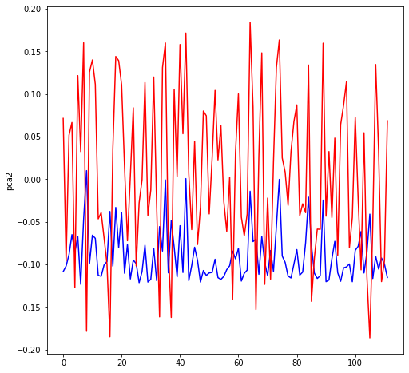

```python
groupg = allxyz[allxyz["class"]==7].drop(["class"], axis=1).T

pca_g = PCA(n_components=2)
pca_data_g=pca_g.fit_transform(groupg)
pca_data_g=pd.DataFrame(pca_data_g)

print("Recovered by the first two components=", np.sum(pca_g.explained_variance_ratio_))

eigenvectorsg=pca_g.components_
eigenvectorsg=pd.DataFrame(eigenvectorsg).T
eigenvectorsg.set_axis(['pca1', 'pca2'], axis=1, inplace=True)
plt.figure(figsize=(8,8))
sns.lineplot(eigenvectorsg.index, eigenvectorsg.pca1, color='b')
sns.lineplot(eigenvectorsg.index, eigenvectorsg.pca2, color='r')
```

```
Recovered by the first two components= 0.7442189158630046
```

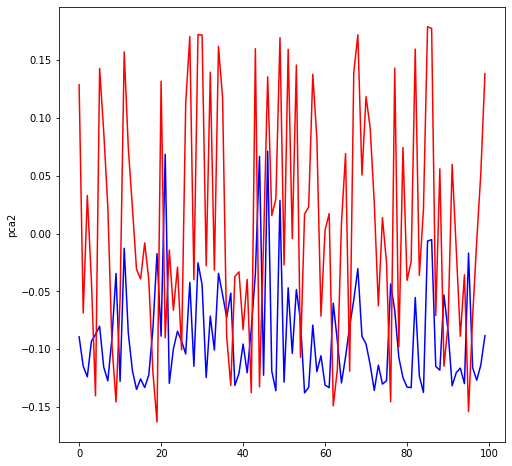

```python
groupg = allxyz[allxyz["class"]==8].drop(["class"], axis=1).T

pca_g = PCA(n_components=2)
pca_data_g=pca_g.fit_transform(groupg)
pca_data_g=pd.DataFrame(pca_data_g)

print("Recovered by the first two components=", np.sum(pca_g.explained_variance_ratio_))

eigenvectorsg=pca_g.components_
eigenvectorsg=pd.DataFrame(eigenvectorsg).T
eigenvectorsg.set_axis(['pca1', 'pca2'], axis=1, inplace=True)
plt.figure(figsize=(8,8))
sns.lineplot(eigenvectorsg.index, eigenvectorsg.pca1, color='b')
sns.lineplot(eigenvectorsg.index, eigenvectorsg.pca2, color='r')
```